# EQ6_TP2_Q2_analyse

Antonio Collante Caro (111 227 429)

Luc Grenier (902 201 689)

03 November, 2019

# 2 Commercialisation et prévisibilité du succès des produits

## 2.1 Préparer les données

Dans cette section, nous devions faire un prétraitement avant d’appeler la fonction `train`.

```
## [1] "data/Q2_data.tsv"
```

Après la préparation, les données montraient 0 donnée manquante.

Voici quelques lignes:

```
## # A tibble: 10 x 18
##    in01     in02  in03  in04  in05  in06  in07  in08 in09   in10  in11
##    <chr>   <dbl> <dbl> <dbl> <dbl> <dbl> <dbl> <dbl> <chr> <dbl> <dbl>
##  1 white 0.0046   0.09  0.08  0.02  10.3 0.17  0.47  very~ 0.037     5
##  2 white 0.0079   0.1   0.06  0.02   8.5 0.18  0.3   very~ 0.028    34
##  3 white 0.0035   0.03  0.03  0.01   4.7 0.785 0     low   0.036    23
##  4 white 0.0099   0.02  0.08  0.04   6.3 0.39  0.35  med   0.04     82
##  5 white 0.0078   0.05  0.01  0.04   7.1 0.32  0.4   very~ 0.034    13
##  6 white 0.0083   0.03  0.08  0.01   7.5 0.290 0.67  very~ 0.037    53
##  7 white 0.0063   0.03  0.05  0.03   6.8 0.22  0.3   very~ 0.07     67
##  8 white 0.00120  0.04  0.06  0.03   8.2 0.42  0.290 med   0.03     31
##  9 red   0.037    0.54  0.47  0.38   9.2 0.36  0.34  very~ 0.062     5
## 10 white 0.0073   0.06  0.06  0.06   5.6 0.2   0.22  very~ 0.049    25
## # ... with 7 more variables: in12 <dbl>, in13 <dbl>, in14 <dbl>,
## #   in15 <dbl>, in16 <chr>, in17 <dbl>, Class <chr>
```

Il est à mentionner que nous avons changé les valeurs de type caractère en entier afin de faciliter l’entrainement.

Les types de colonnes sont corrects, certains sont des entiers et d’autres des nombres naturels ainsi qu’une colonne de type *factor*. Tel qu’illustrer ci contre:

```
## Classes 'tbl_df', 'tbl' and 'data.frame':    6497 obs. of  18 variables:
##  $ in01 : num  1 1 1 1 1 1 1 1 2 1 ...
##  $ in02 : num  0.0046 0.0079 0.0035 0.0099 0.0078 0.0083 0.0063 0.0012 0.037 0.0073 ...
##  $ in03 : num  0.09 0.1 0.03 0.02 0.05 0.03 0.03 0.04 0.54 0.06 ...
##  $ in04 : num  0.08 0.06 0.03 0.08 0.01 0.08 0.05 0.06 0.47 0.06 ...
##  $ in05 : num  0.02 0.02 0.01 0.04 0.04 0.01 0.03 0.03 0.38 0.06 ...
##  $ in06 : num  10.3 8.5 4.7 6.3 7.1 7.5 6.8 8.2 9.2 5.6 ...
##  $ in07 : num  0.17 0.18 0.785 0.39 0.32 0.29 0.22 0.42 0.36 0.2 ...
##  $ in08 : num  0.47 0.3 0 0.35 0.4 0.67 0.3 0.29 0.34 0.22 ...
##  $ in09 : num  1 1 2 3 1 5 5 3 1 1 ...
##  $ in10 : num  0.037 0.028 0.036 0.04 0.034 0.037 0.07 0.03 0.062 0.049 ...
##  $ in11 : num  5 34 23 82 13 53 67 31 5 25 ...
##  $ in12 : num  33 95 134 260 84 166 194 100 12 155 ...
##  $ in13 : num  0.994 0.993 0.99 0.994 0.994 ...
##  $ in14 : num  2.89 2.83 3.53 3.12 3.42 2.9 2.89 3 3.2 3.74 ...
##  $ in15 : num  0.28 0.36 0.92 0.66 0.6 0.41 0.42 0.32 0.67 0.43 ...
##  $ in16 : num  1 2 3 2 2 1 1 2 2 2 ...
##  $ in17 : num  24.1 26.4 28.9 27.7 19.6 ...
##  $ Class: Factor w/ 2 levels "no","yes": 1 1 1 1 1 1 1 2 1 1 ...
```

## 2.2 Entraînements

Nous avons choisi deux modèles pour la prédiction de la probabilité de succès d’une classement. Ces deux modèles sont *RPART* et *Boosted Trees*. De plus, nous avons retiré certaines colonnes qui représentaient une trop grande corrélation entre elles, le cutoff a été établi à .75. Nous avons créé aussi les partitions selon la règle 80:20.

### Modèle RPART

Pour notre grille de tuples, nous avons utilisé les paramètres suivants pour le modèle *rpart2* : `expand.grid(maxdepth = 1:10)`

```
## [1] "Load model from file"
```

```
## Confusion Matrix and Statistics
##
##           Reference
## Prediction   no  yes
##        no  1006  207
##        yes   38   48
##
##                Accuracy : 0.8114
##                  95% CI : (0.789, 0.8323)
##     No Information Rate : 0.8037
##     P-Value [Acc > NIR] : 0.2547
##
##                   Kappa : 0.2026
##
##  Mcnemar's Test P-Value : <2e-16
##
##             Sensitivity : 0.18824
##             Specificity : 0.96360
##          Pos Pred Value : 0.55814
##          Neg Pred Value : 0.82935
##              Prevalence : 0.19630
##          Detection Rate : 0.03695
##    Detection Prevalence : 0.06620
##       Balanced Accuracy : 0.57592
##
##        'Positive' Class : yes
##
```

```
##
## data.predict.rpart   no  yes
##                no  1006  207
##                yes   38   48
```

### Modèle Boosted Trees

Ici, afin de minimiser le temps de calcul, nous avons limité la validation croisée à 5 plutôt que 10 pour le *rpart*. Pour notre grille de tuples, nous avons utilisé les paramètres suivants pour le modèle *gbm* :

```r
expand.grid(interaction.depth = c(1, 5, 9),
                            n.trees = seq(100,1000,by = 100),
                            shrinkage = 0.1,
                            n.minobsinnode = 10
```

```
## [1] "Load model from file"
```

```
## Confusion Matrix and Statistics
##
##           Reference
## Prediction  no yes
##        no  989 127
##        yes  55 128
##
##                Accuracy : 0.8599
##                  95% CI : (0.8398, 0.8783)
##     No Information Rate : 0.8037
##     P-Value [Acc > NIR] : 6.927e-08
##
##                   Kappa : 0.5029
##
##  Mcnemar's Test P-Value : 1.418e-07
##
##             Sensitivity : 0.50196
##             Specificity : 0.94732
##          Pos Pred Value : 0.69945
##          Neg Pred Value : 0.88620
##              Prevalence : 0.19630
##          Detection Rate : 0.09854
##    Detection Prevalence : 0.14088
##       Balanced Accuracy : 0.72464
##
##        'Positive' Class : yes
##
```

```
##
## data.predict.gbm  no yes
##              no  989 127
##              yes  55 128
```

## 2.3 Afficher l’arbre de décision appris

Voici l’arbre de décision suite à l’analyse.

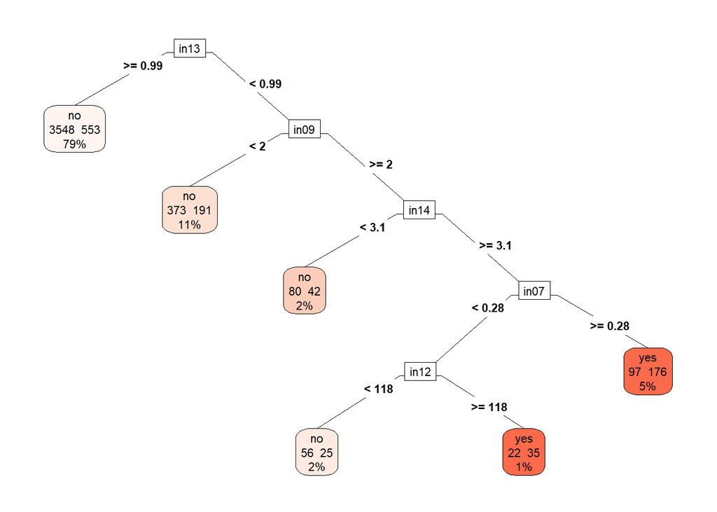

## 2.4 Évaluation de l’entraînement pour chacun des modèles

### 2.4.1 Modèle RPART

La Figure 1 montre la valeur de l’exactitude par rapport à la profondeur de l’arbre dans notre modèle. Nous pouvons constater que l’exactitude du modèle plafone à partir d’une profondeur de 7. Ainsi, 7 est la meilleure valeur pour le paramètre *maxdepth* (profondeur de l’arbre) ici. Nous obtenons une exactitude de 0.8114 pour ce modèle.

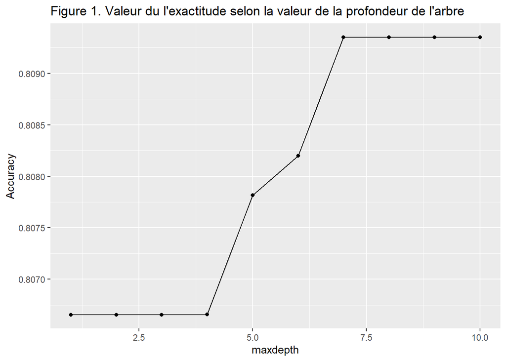

### Modèle Boosted Trees

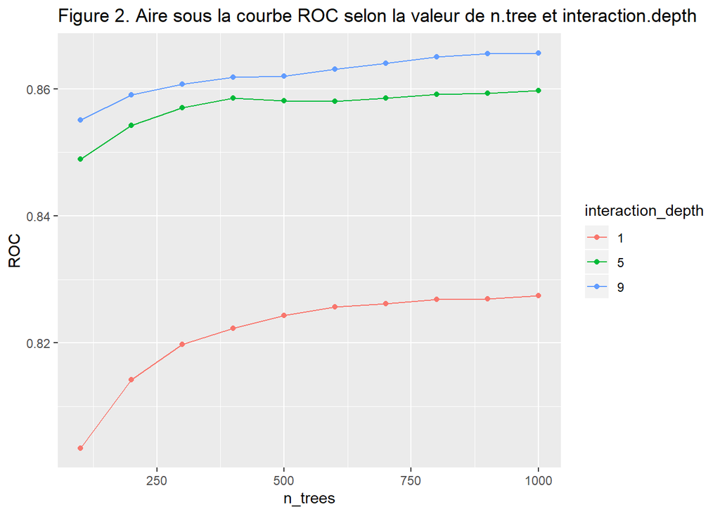

## 2.5 Comparaison des modèles

La Figure 3 présente la comparaison des courbes ROC de chacun des modèles. Nous pouvons constater rapidement que le modèle *Bossted trees* (gbm) présente une aire sous la courbe plus importante que le modèle *rpart*. En effet, l’aire sous la courbe ROC de *gbm* est de **0.8795733** , tandis que celle de *rpart* est de **0.6489032**. Ceci démontre que le modèle *gbm* est supérieur à *rpart* dans cette situation. À noter que le temps de calcul de *gbm* a été beaucoup plus long que *rpart*, ce qui peut être non négligeable, surtout si *rpart* présente une solution satisfaisante.

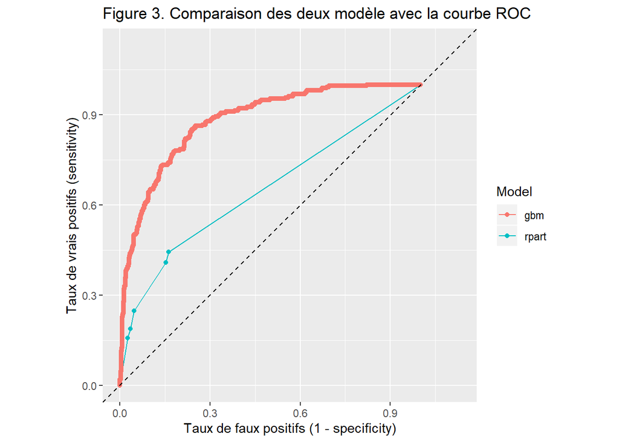